# NYC energy efficiency classification

Andrés Camargo

2023-05-06

https://data.cityofnewyork.us/Environment/Energy-and-Water-Data-Disclosure-for-Local-Law-84-/wcm8-aq5w https://www.kaggle.com/code/winternguyen/modeling-energy-efficiency-residential-building https://www.urbangreencouncil.org/new-york-citys-2020-energy-and-water-use-report/

## 1. Case Description

This project aims to develop a classification model using supervised learning techniques to identify energy-efficient buildings in New York City. The dataset used for this project is provided by [NYC Open Data](https://data.cityofnewyork.us/Environment/Energy-and-Water-Data-Disclosure-for-Local-Law-84-/wcm8-aq5w) and consists of reports on more than 29,000 buildings and 254 features for the calendar year 2019. The identification of energy-efficient buildings is crucial for achieving NYC’s ambitious goal of 100% carbon-free electricity and reducing emissions by 2040. This model will aid in benchmarking and achieving decarbonization goals.

```r
library(tidyverse)
```

```r
library(ggplot2)
library(DataExplorer)
library(caret)
library(forcats)
library(factoextra)
library(cluster)
library(mclust)
library(GGally)
library(plotly)
library(sf)
library(rnaturalearth)
library(rnaturalearthdata)
library(ggthemes)
library(pROC)
library(sjPlot)
data = read.csv("Energy_and_Water_Data_Disclosure_for_Local_Law_84_2020__Data_for_Calendar_Year_2019_.csv")

#head(data)
#nrow(data)
#ncol(data)
```

## 2. Cleaning and Feature Engineering

In addition, we do some **feature engineering**. In order to build comparable variables that are computed as total volumes, we divided them by the size of the buildings. As a result, we achieve a subset of 13 variables and more than 2000 observations. We didn’t include more features because many of the original variables were disaggregated measures of those that we chose.

Our final features are listed below:

- Energy-Star Score
- Occupancy per $m^2$: $People/ft^2$
- Weather Normalized Source Energy Use Intensity (EUI):$kBtu/ft^2$
- Fuel Oil Use: $kBtu/ft^2$
- Weather Normalized Site Natural Gas Use: $therms/ft^2$
- Weather Normalized Site Grid Purchased Electricity: $kWh/ft^2$
- Electricity Use, generated from Onsite Renewable Systems: $kWh/ft^2$
- Total GHG Emissions $Metric Tons CO2e/ft^2)$
- Water Use Intensity All Water Sources (WUI): $gal/ft^2)$
- Gross Floor Area $ft^2$
- Use type
- Longitude
- Latitude

```r
building_type = data %>% select(Property.Id, Largest.Property.Use.Type)

clean_ny = data %>%
  # feature selection
  select(c(Largest.Property.Use.Type...Gross.Floor.Area..ft.., ENERGY.STAR.Score,
           Occupancy, Weather.Normalized.Source.EUI..kBtu.ft..,
           Weather.Normalized.Source.Energy.Use..kBtu., Fuel.Oil..2.Use..kBtu.,
           Weather.Normalized.Site.Natural.Gas.Use..therms.,
           Weather.Normalized.Site.Electricity..kWh.,
           Electricity.Use...Grid.Purchase.and.Generated.from.Onsite.Renewable.Systems..kWh.,
           Total.GHG.Emissions..Metric.Tons.CO2e.,  Water.Use..All.Water.Sources...kgal.,
           Water.Use.Intensity..All.Water.Sources...gal.ft.., Property.Id,
           Latitude,
           Longitude
           )) %>%
  mutate(across(where(is.character), as.integer)) %>%
  # Discarting NAs
  drop_na() %>%
  #Renaming variables
  rename(area = 1,
         energy_score = 2,
         occupancy = 3,
         eui = 4,
         energy_use = 5,
         fueloil_use = 6,
         gas_use = 7,
         electricity_grid_use = 8,
         renewables_use = 9,
         ghg_emissions = 10,
         water_use = 11,
         wui = 12
         ) %>%
  # Feature engineering
  mutate(
    occupancy_pa = occupancy/area,
    fueloil_use_pa = fueloil_use/area,
    gas_use_pa = gas_use/area,
    electricity_useGP_pa = electricity_grid_use/area,
    renewables_use_pa = renewables_use/area,
    ghg_emissions_pa = ghg_emissions/area,
  ) %>%
  select(!c(energy_use, water_use, occupancy, fueloil_use,gas_use,electricity_grid_use,renewables_use, ghg_emissions)) %>%
  left_join(building_type, by = 'Property.Id' ) %>%
  rename(type = Largest.Property.Use.Type) %>%
  mutate(type = as.factor(type))

head(clean_ny)
```

```
##      area energy_score eui wui Property.Id Latitude Longitude occupancy_pa
## 1  308789           38 469  79       28404 40.87239 -73.91267 3.238457e-04
## 2  885474           66 147   4     1143922 40.70455 -74.00664 6.776032e-05
## 3 1852980           92 105  11     1143934 40.72066 -74.01010 5.396712e-05
## 4 1414803           67 160  14     1409171 40.74670 -73.94348 7.068122e-05
## 5 1414803           67 160  14     1409171 40.74670 -73.94348 7.068122e-05
## 6  437571           96  80   4     1409173 40.74757 -73.94352 2.285343e-04
##   fueloil_use_pa  gas_use_pa electricity_useGP_pa renewables_use_pa
## 1     0.00000000 1.619908740            31.366687         31.750652
## 2     0.00000000 0.000000000            11.655381         11.655385
## 3     0.03068355 0.190909238             8.750489          8.750488
## 4     0.00000000 0.002825835            16.994128         17.150692
## 5     0.00000000 0.002825835            16.994128         17.150692
## 6     1.16847323 0.071743786             9.215922          9.215924
##   ghg_emissions_pa                                  type
## 1      0.017212401 Hospital (General Medical & Surgical)
## 2      0.005346289                                Office
## 3      0.003669225                                Office
## 4      0.004970303                                Office
## 5      0.004970303                                Office
## 6      0.003128635                                Office
```

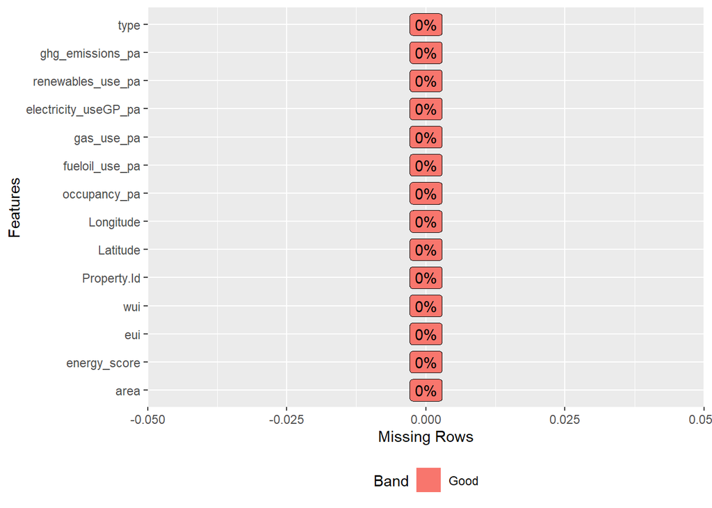

```r
plot_missing(clean_ny)
```

## 3. Exploratory Analysis

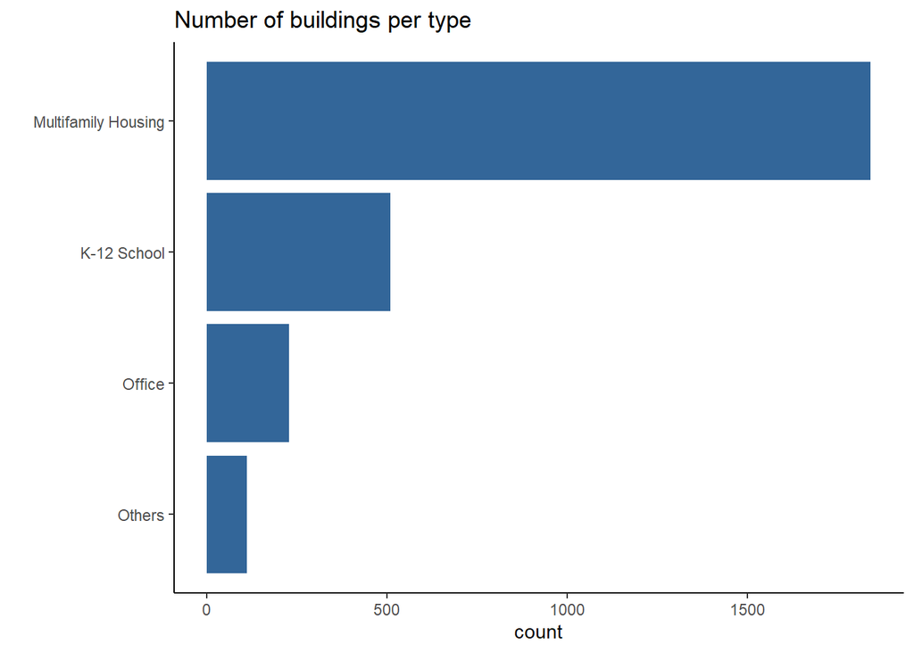

```r
clean_ny <- clean_ny %>%
  mutate(type = if_else(type %in% c("Multifamily Housing"), "Multifamily Housing",
                      if_else(type %in% c("K-12 School"), "K-12 School",
                              if_else(type %in% c("Office"), "Office", "Others")))) %>%
  mutate(area = case_when(
    area <= 50000 ~ "midsize",
    area > 50000 & area <= 500000 ~ "large",
    area > 500000 ~ "very large",
  )) %>% mutate(area=as.factor(area))

clean_ny %>% ggplot(aes(y=fct_rev(fct_infreq(type)))) +
  geom_bar(fill="#336699") +
  labs(title= "Number of buildings per type") +
  ylab("") +
  theme_classic()
```

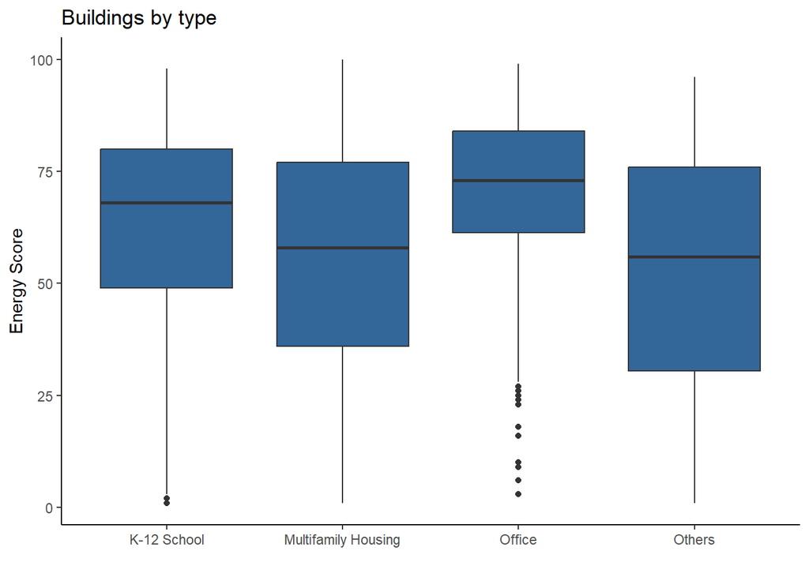

```r
clean_ny %>% ggplot(aes(type, energy_score)) +
  geom_boxplot(fill="#336699") +
  labs(title= "Buildings by type", y="Energy Score", x="") +
  theme_classic()
```

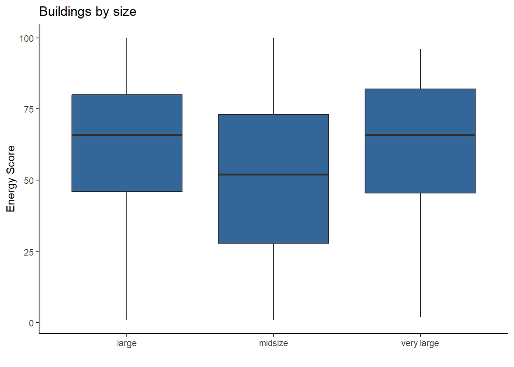

```r
clean_ny %>% ggplot(aes(area, energy_score)) +
  geom_boxplot(fill="#336699") +
  labs(title= "Buildings by size",  y="Energy Score", x="") +
  theme_classic()
```

```r
#table(clean_ny$type)/length(clean_ny$type)
```

### Removing outliers

The boxplots depicted below indicate the presence of numerous outliers in the majority of variables. To address this, we utilize the Interquartile Range Rule and remove the outliers from the dataset.

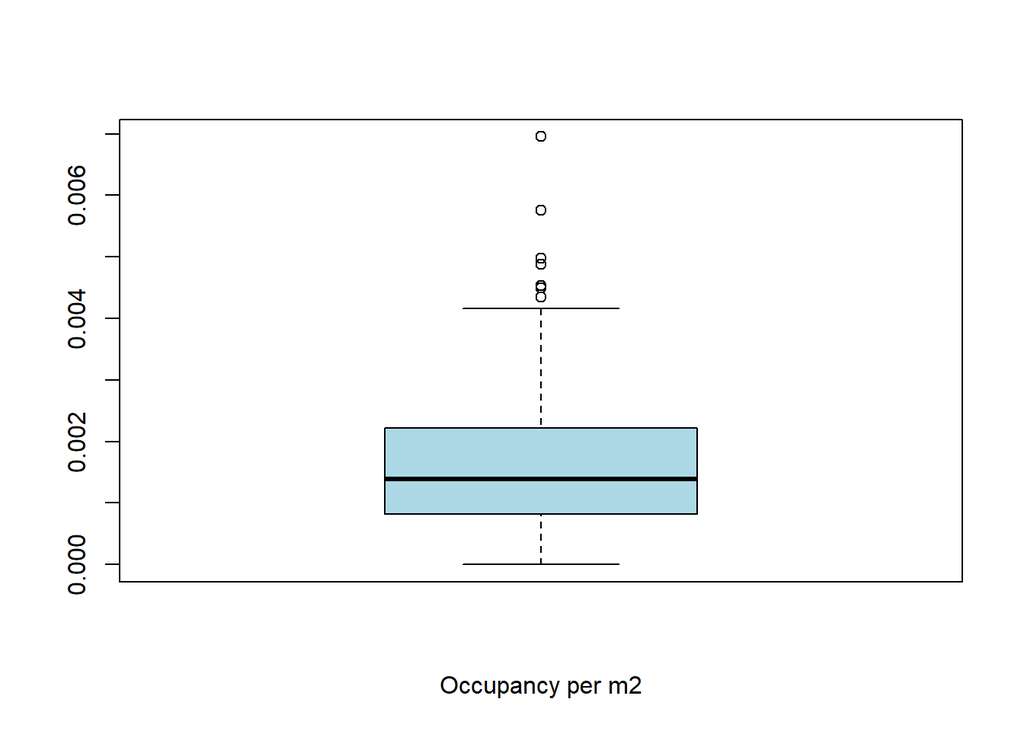

```r
boxplot(clean_ny$occupancy_pa, xlab="Occupancy per m2", col="lightblue")
```

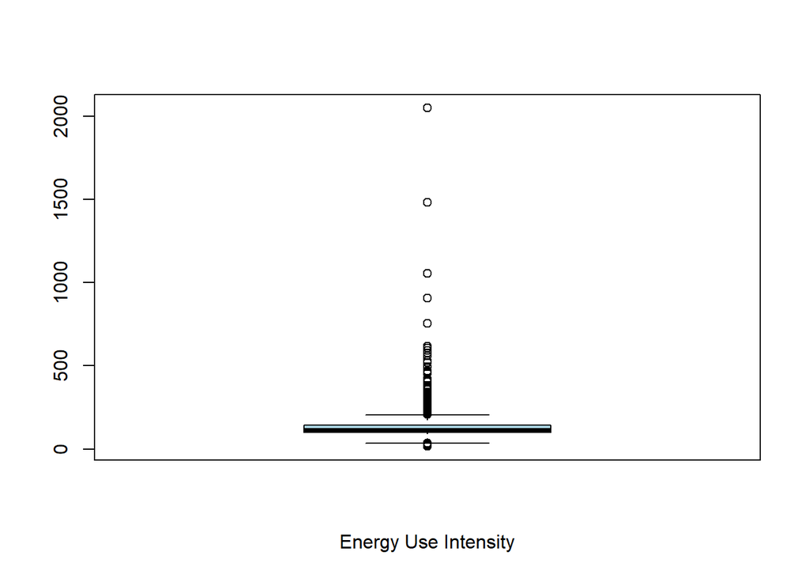

```r
boxplot(clean_ny$eui, xlab="Energy Use Intensity", col="lightblue")
```

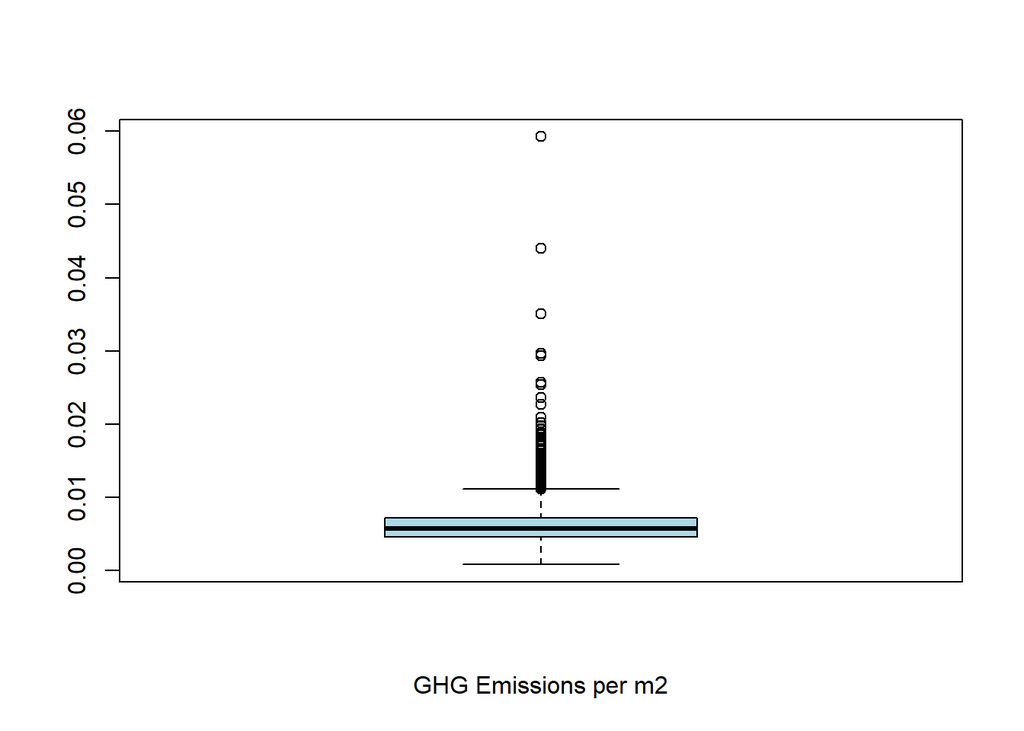

```r
boxplot(clean_ny$ghg_emissions_pa, xlab="GHG Emissions per m2", col="lightblue")
```

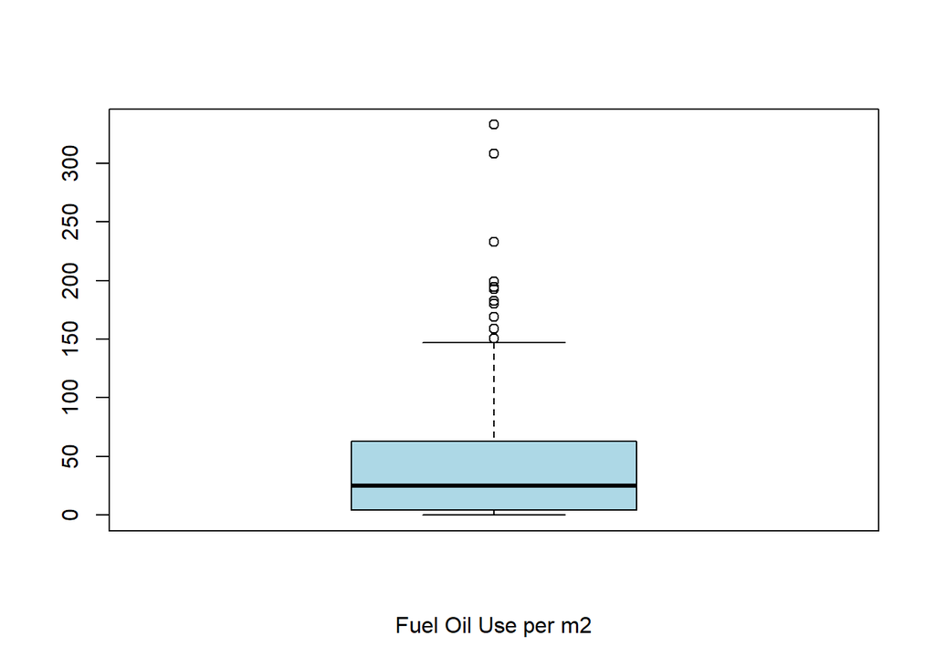

```r
boxplot(clean_ny$fueloil_use_pa, xlab="Fuel Oil Use per m2", col="lightblue")
```

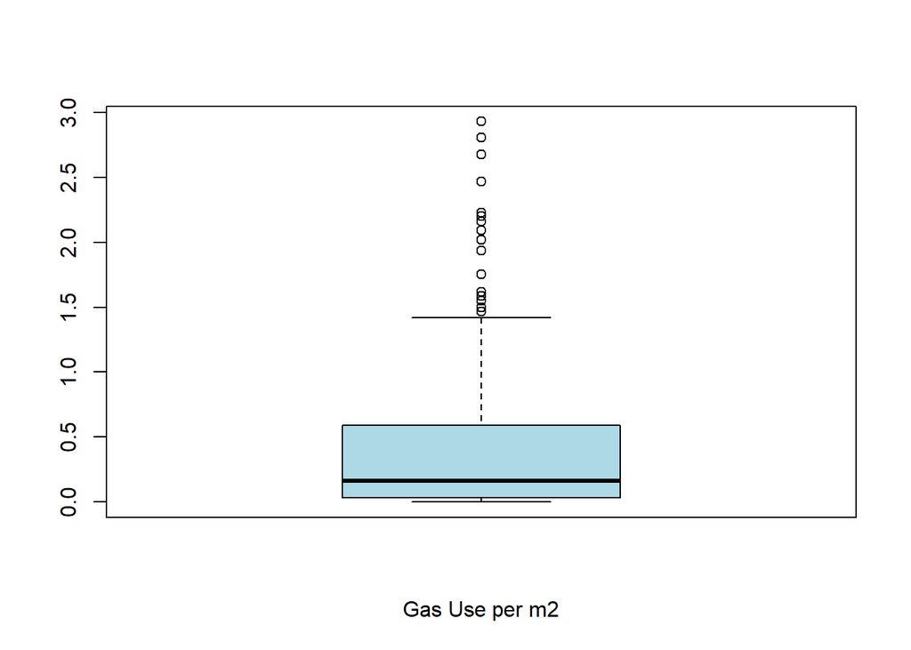

```r
boxplot(clean_ny$gas_use_pa, xlab="Gas Use per m2", col="lightblue")
```

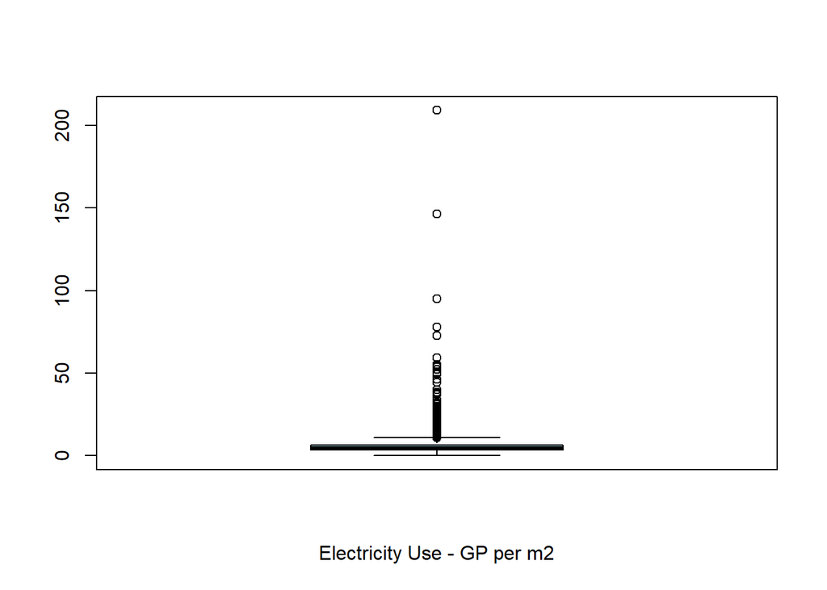

```r
boxplot(clean_ny$electricity_useGP_pa, xlab="Electricity Use - GP per m2", col="lightblue")
```

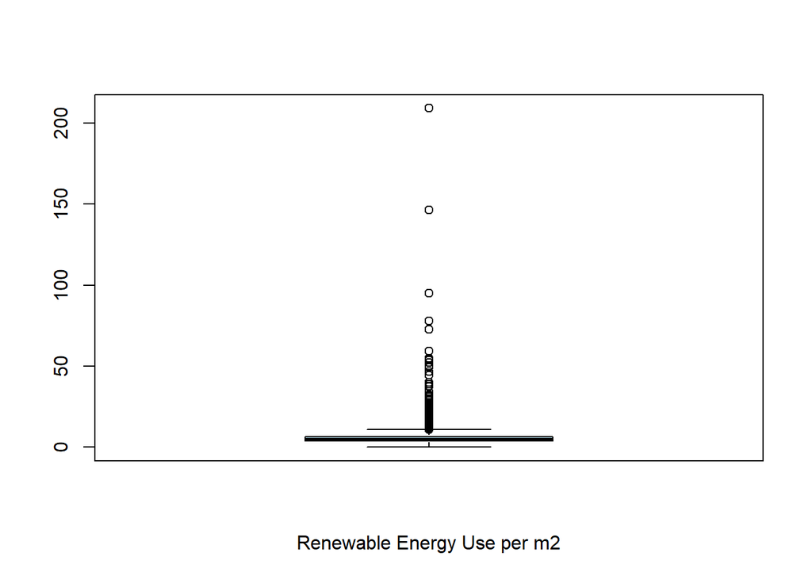

```r
boxplot(clean_ny$renewables_use_pa, xlab="Renewable Energy Use per m2", col="lightblue")
```

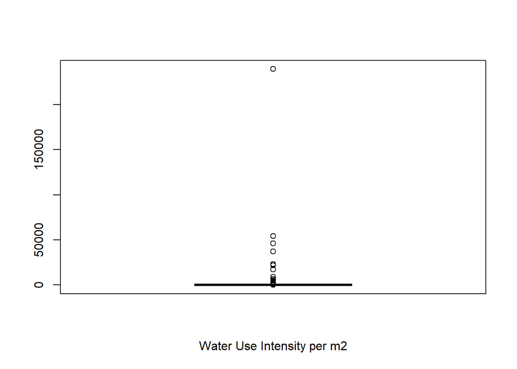

```r
boxplot(clean_ny$wui, xlab="Water Use Intensity per m2", col="lightblue")
```

```r
detect_outliers = function(x){
  q1 = quantile(x, probs=.25)
  q3 = quantile(x, probs=.75)
  iqr = q3-q1
  x > (q3 + (iqr*1.5)) | x < (q1-(iqr*1.5) )
}

rmv_outliers = function(dataframe, columns=names(dataframe)) {

    for (col in columns) {
        dataframe <- dataframe[!detect_outliers(dataframe[[col]]), ]
    }

  dataframe
}

buildings_clean = rmv_outliers(clean_ny, c("occupancy_pa", "eui",
          "fueloil_use_pa","gas_use_pa","electricity_useGP_pa","renewables_use_pa","ghg_emissions_pa","wui" ))
```

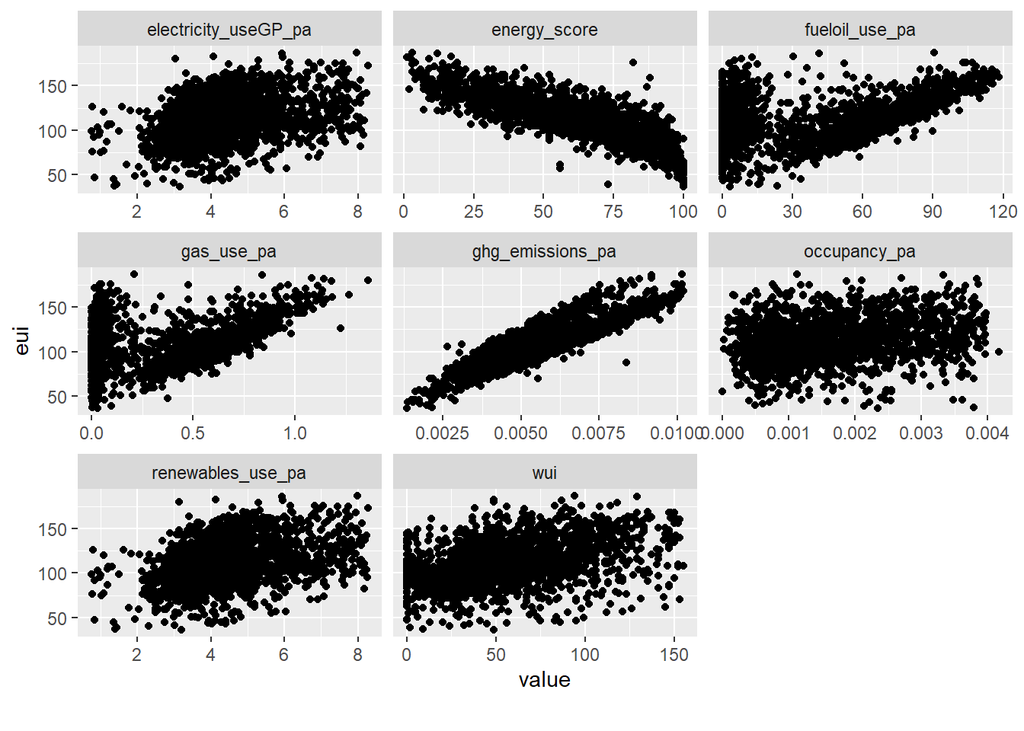

```r
# Select continuous variables
ny_buildings = buildings_clean %>% select(!c(Property.Id,type, Latitude, Longitude, area))
plot_scatterplot(ny_buildings, by="eui")
```

```r
#types = buildings_clean$type
#ids = buildings_clean$Property.Id
```

### Correlations

The analysis of the correlations reveals that most of our predictors are negatively correlated with the energy score, suggesting as hypothesis that higher resource consumption is associated with lower energy efficiency. We also detected multicollinearity between the variables of renewable energy use and electricity use from the grid. These variables measure similar characteristics in terms of energy consumption and have a perfect correlation, leading us to discard the renewable energy variable.

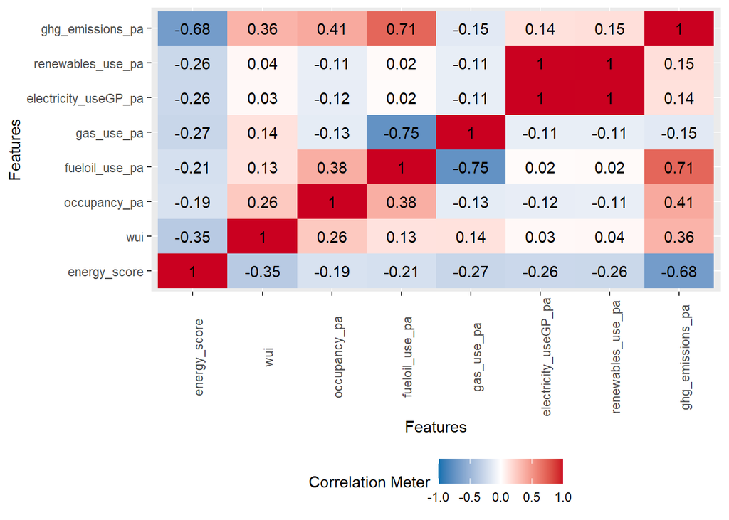

```r
## REvisar que la variable de renovables corresponda solo a renovables
plot_correlation(ny_buildings %>% select(!eui))
```

### Target variable

```r
ny_buildings = buildings_clean %>% select(!c(Property.Id))
ny_buildings = ny_buildings %>% mutate(
  efficiency = as.factor(ifelse(energy_score > 75, "Yes", "No"))
) %>% select(!energy_score)
```

## 3. Modeling

### Train-test split

```r
set.seed(163)
# split data
in_train <- createDataPartition(ny_buildings$efficiency, p = 0.75, list = FALSE)
training <- ny_buildings[in_train,]
testing <- ny_buildings[-in_train,]
```

### Cross validation (10 folds)

```r
ctrl = trainControl(
  method = "repeatedcv",
  number = 10,
  classProbs = T,
  summaryFunction = twoClassSummary,
  verboseIter = T
  )
```

### Training a Logistic regression

We chose to begin with a logistic regression model because it enables us to model the probability of a binary target variable, and its results are highly interpretable.

```r
logistic = train(
  efficiency ~
    area+wui+occupancy_pa+fueloil_use_pa+gas_use_pa+electricity_useGP_pa+ghg_emissions_pa+
    type,
  data = training,
  method= "glm",
  family = "binomial",
  metric = "ROC",
  preProc= c('scale', 'center'),
  tuneLength= 10,
  trControl = ctrl)
#model summary
summary(logistic$finalModel)
```

```
##
## Call:
## NULL
##
## Deviance Residuals:
##     Min       1Q   Median       3Q      Max
## -4.5008  -0.6188  -0.1958   0.5459   3.8075
##
## Coefficients:
##                           Estimate Std. Error z value Pr(>|z|)
## (Intercept)               -1.27654    0.08930 -14.295  < 2e-16 ***
## areamidsize               -0.04268    0.13892  -0.307    0.759
## `areavery large`           0.08968    0.06739   1.331    0.183
## wui                       -0.01075    0.08745  -0.123    0.902
## occupancy_pa               0.09591    0.14486   0.662    0.508
## fueloil_use_pa             0.32039    0.42923   0.746    0.455
## gas_use_pa                -1.25257    0.30769  -4.071 4.68e-05 ***
## electricity_useGP_pa      -0.59994    0.10808  -5.551 2.85e-08 ***
## ghg_emissions_pa          -2.60900    0.31388  -8.312  < 2e-16 ***
## `typeMultifamily Housing`  0.40381    0.09461   4.268 1.97e-05 ***
## typeOffice                 0.32134    0.08181   3.928 8.57e-05 ***
## typeOthers                 0.46669    0.09677   4.823 1.42e-06 ***
## ---
## Signif. codes:  0 '***' 0.001 '**' 0.01 '*' 0.05 '.' 0.1 ' ' 1
##
## (Dispersion parameter for binomial family taken to be 1)
##
##     Null deviance: 1981.1  on 1537  degrees of freedom
## Residual deviance: 1176.5  on 1526  degrees of freedom
## AIC: 1200.5
##
## Number of Fisher Scoring iterations: 6
```

```r
tab_model(logistic$finalModel)
```

|  | Dependent variable |  |  |
| --- | --- | --- | --- |
| Predictors | Odds Ratios | CI | p |
| (Intercept) | 0.28 | 0.23 – 0.33 | **<0.001** |
| areamidsize | 0.96 | 0.73 – 1.26 | 0.759 |
| areavery large | 1.09 | 0.96 – 1.25 | 0.183 |
| wui | 0.99 | 0.83 – 1.17 | 0.902 |
| occupancy pa | 1.10 | 0.83 – 1.46 | 0.508 |
| fueloil use pa | 1.38 | 0.64 – 3.54 | 0.455 |
| gas use pa | 0.29 | 0.16 – 0.56 | **<0.001** |
| electricity useGP pa | 0.55 | 0.44 – 0.68 | **<0.001** |
| ghg emissions pa | 0.07 | 0.04 – 0.13 | **<0.001** |
| typeMultifamily Housing | 1.50 | 1.25 – 1.81 | **<0.001** |
| typeOffice | 1.38 | 1.18 – 1.63 | **<0.001** |
| typeOthers | 1.59 | 1.32 – 1.92 | **<0.001** |
| Observations | 1538 |  |  |
| R<sup>2</sup> Tjur | 0.463 |  |  |

### Evaluation

```r
log_prediction <- predict(logistic,testing,type="prob")
prediction = as.factor(ifelse(log_prediction[,2]>0.5, "Yes", "No"))

confusionMatrix(prediction, testing$efficiency)
```

```
## Confusion Matrix and Statistics
##
##           Reference
## Prediction  No Yes
##        No  295  28
##        Yes  41 148
##
##                Accuracy : 0.8652
##                  95% CI : (0.8326, 0.8936)
##     No Information Rate : 0.6562
##     P-Value [Acc > NIR] : <2e-16
##
##                   Kappa : 0.7065
##
##  Mcnemar's Test P-Value : 0.1486
##
##             Sensitivity : 0.8780
##             Specificity : 0.8409
##          Pos Pred Value : 0.9133
##          Neg Pred Value : 0.7831
##              Prevalence : 0.6562
##          Detection Rate : 0.5762
##    Detection Prevalence : 0.6309
##       Balanced Accuracy : 0.8594
##
##        'Positive' Class : No
##
```

```r
roc(testing$efficiency, log_prediction[,2])$auc
```

```
## Area under the curve: 0.9229
```

The model’s performance metrics are satisfactory, but we would like to explore an alternative machine learning model to investigate if other non-linear variables, such as longitude and latitude, could affect the results.

### Fit Random Forest

```r
rfFit = train(
  efficiency ~
    area+wui+occupancy_pa+fueloil_use_pa+gas_use_pa+electricity_useGP_pa+ghg_emissions_pa+
    type+Longitude+Latitude,
  data = training,
  method= "rf",
  preProc= c('scale', 'center'),
  tuneLength= 10,
  metric = "ROC",
  trControl = ctrl
)
rfProb = predict(rfFit, testing, type = "prob")
prediction = as.factor(ifelse(rfProb[,2]>0.5, "Yes", "No"))

confusionMatrix(prediction, testing$efficiency)
```

```
## Confusion Matrix and Statistics
##
##           Reference
## Prediction  No Yes
##        No  298  31
##        Yes  38 145
##
##                Accuracy : 0.8652
##                  95% CI : (0.8326, 0.8936)
##     No Information Rate : 0.6562
##     P-Value [Acc > NIR] : <2e-16
##
##                   Kappa : 0.7041
##
##  Mcnemar's Test P-Value : 0.4701
##
##             Sensitivity : 0.8869
##             Specificity : 0.8239
##          Pos Pred Value : 0.9058
##          Neg Pred Value : 0.7923
##              Prevalence : 0.6562
##          Detection Rate : 0.5820
##    Detection Prevalence : 0.6426
##       Balanced Accuracy : 0.8554
##
##        'Positive' Class : No
##
```

After comparing the results of the logistic regression and the machine learning model, we found that the predictions are not significantly affected by the inclusion of non-linear variables such as longitude and latitude. However, we still wanted to assess the importance of variables for prediction and evaluate the AUC to gain a better understanding of the model’s performance.

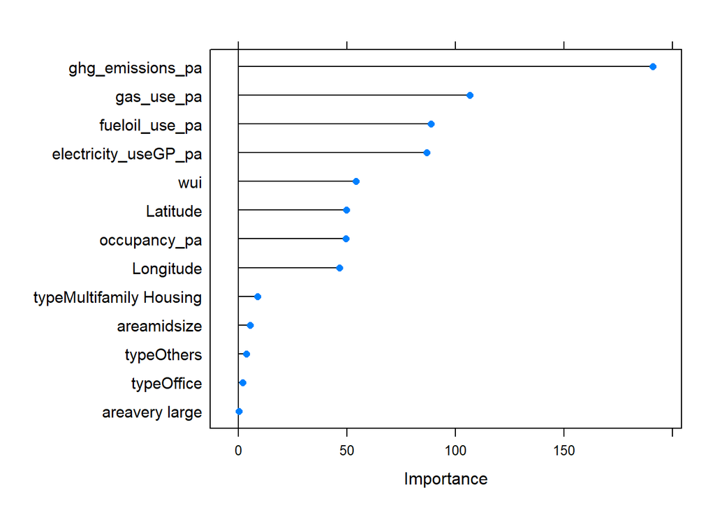

```r
plot(varImp(rfFit, scale = F), scales = list(y = list(cex = .95)))
```

```r
roc(testing$efficiency, rfProb[,2])$auc
```

```
## Area under the curve: 0.9426
```

### 5. Conclussions

We have confirmed that buildings that consume more resources are less likely to be energy-efficient, and our predictions have been highly accurate. Our models have provided different approaches to the problem at hand. The logistic regression model has shown the clear effect of predictors on our response variable. The random forest model increased the AUC, but didn’t significantly improve other performance metrics. Finally, we have visualized the geographical distribution of energy-efficient buildings in NYC.

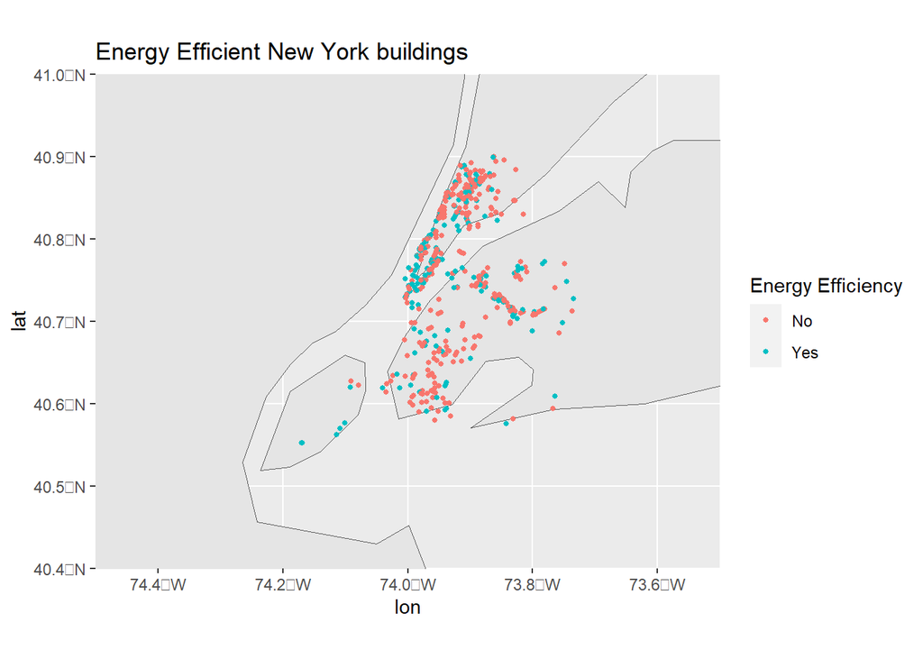

```r
world <- ne_countries(scale = "medium", returnclass = "sf")

sites <- data.frame(lon = testing$Longitude, lat= testing$Latitude, efficiency=prediction)

ggplot(data = world) +
    geom_sf() +
    geom_point(data = sites, aes(x = lon, y = lat, color=factor(efficiency)), size = 1) +
    coord_sf(xlim = c(-73.5, -74.5), ylim = c(40.4, 41), expand = FALSE) +
  ggtitle("Energy Efficient New York buildings") +
  labs(color = "Energy Efficiency")
```